# SVM on Forest Fires

Used the resources provided and my own knowledge:  
https://www.svm-tutorial.com/2014/10/support-vector-regression-r/

## Start

### Loading Libraries and Data

```r
# load packages
suppressWarnings(library(tidyverse)) #for ggplot and dplyr
library(corrplot) #for correlation plots
library(rattle)
library(caTools)
library(e1071)
```

```r
setwd("C:/Users/ezhou/OneDrive - Eastside Preparatory School/Documents/Eric/2022 - 2023/1 Fall/A Data Science/Forest Fires")
forestRaw <- read.csv("forestfires.csv")
```

### Data Preprocessing

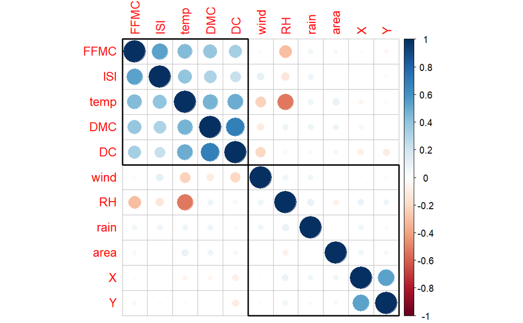

```r
# summary(forestRaw)

forestNum <- forestRaw %>% select(-month, -day)
corrs <- cor(forestNum)
corrplot(corrs, order = 'hclust', addrect = 2)
```

```r
# RMSE function
myRMSE <- function(pred, obs) {
  return(sqrt(mean((pred - obs) ^ 2, na.rm = TRUE)))
}
```

```r
forestNum <- forestNum %>% mutate(logArea = log(area+1))
forestNum <- forestNum %>% select(-area)
# summary(forestNum)
```

## Support Vector Regression

The package name “e1071” is the code of the statistics department at the Vienna University of Technology. Based on my understanding, SVR tries to get the best fit line in multidimension and can be of many different forms, determined by the kernel type. In regression, this line is used to predict values while in classification, lines are draw to separate different categories as well as possible.

### Splitting Data

```r
set.seed(49301) # keeping the same seed as the other file
ind <- sample.split(Y=forestNum, SplitRatio=0.8)
trainData <- forestNum[ind,]
testData <- forestNum[-ind,]
```

### Building model

```r
start <- Sys.time()
model <- svm(logArea ~ ., trainData)
end <- Sys.time()
(time <- end - start)
```

```
Time difference of 0.09496498 secs
```

Training is super fast, only took ~0.095 seconds to run

### Evaluating Model

```r
pred_y = predict(model, testData)
myRMSE(pred_y, testData$logArea)
```

```
[1] 1.362002
```

Starting RMSE is not bad but not good either.

### Tuning time :)

```r
start <- Sys.time()
# perform a grid search
tuneResult <- tune(svm, logArea ~ .,  data = trainData, ranges = list(epsilon = seq(0,1,0.1), cost = 2^(2:9)))
print(tuneResult)
```

```
Parameter tuning of ‘svm’:

- sampling method: 10-fold cross validation

- best parameters:
```

|  | epsilon | cost |
| --- | --- | --- |
|  | 0.7 | 4 |

```
- best performance: 2.155758
```

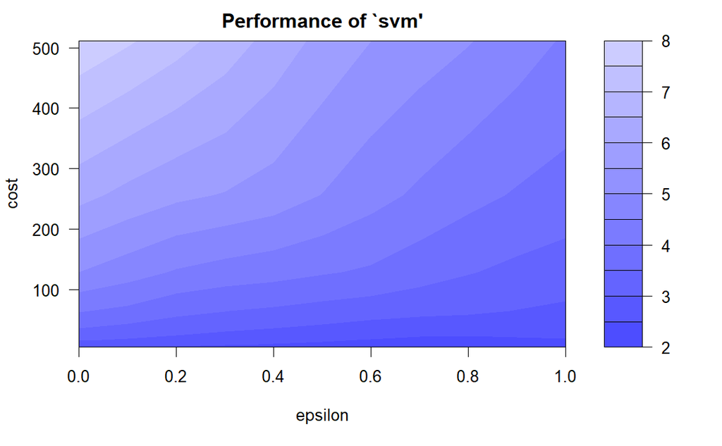

```r
# Draw the tuning graph
plot(tuneResult)
```

```r
tunedModel <- tuneResult$best.model
end <- Sys.time()
(time <- end - start)
```

```
Time difference of 50.21137 secs
```

Pretty fast, took around ~50 seconds to run. RMSE is not very good though.

```r
pred_y2 = predict(tunedModel, testData)
myRMSE(pred_y2, testData$logArea)
```

```
[1] 1.275997
```

```r
start <- Sys.time()
# perform a grid search
tuneResult2 <- tune(svm, logArea ~ .,  data = trainData, ranges = list(epsilon = seq(0.6,0.8,0.01), cost = 2^(0:5)))
print(tuneResult2)
```

```
Parameter tuning of ‘svm’:

- sampling method: 10-fold cross validation

- best parameters:
```

|  | epsilon | cost |
| --- | --- | --- |
|  | 0.7 | 1 |

```
- best performance: 2.036513
```

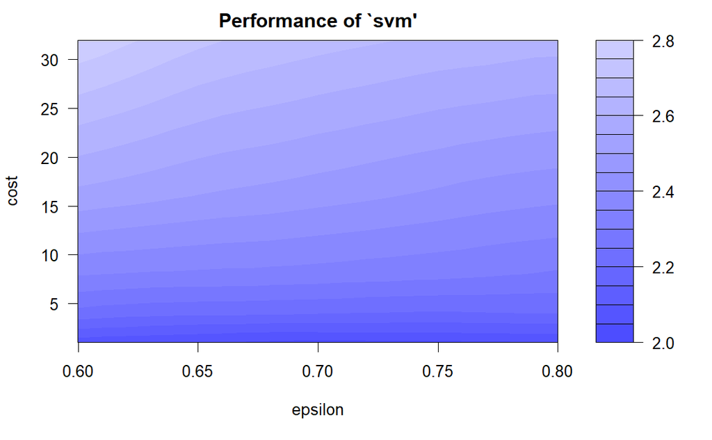

```r
plot(tuneResult2)
```

```r
tunedModel2 <- tuneResult2$best.model
end <- Sys.time()
(time <- end - start)
```

```
Time difference of 31.33706 secs
```

```r
pred_y3 = predict(tunedModel2, testData)
myRMSE(pred_y3, testData$logArea)
```

```
[1] 1.336714
```

SVR did not perform as well as I had hoped. This additional tuning has a worse RMSE value than the earlier model. I also tried with gamma earlier but it also got worse. I played with kernels for a bit as well but got some errors, might try it in class when we have more time. The best RMSE from SVM is ~1.276, which is worse than pretty much everything else except for decision tree. My best decision tree got to ~1.33 and my best random forest was at ~0.93. The tuned XGBoost got all the way down to ~0.81. The NN got to 1.160745.

```r
set.seed(49301)
start <- Sys.time()
best <- c(100, -1, -1, -1)
for (j in 1:25){
  for (k in 1:25) {
    for (l in seq(0.1, 1, 0.1)){
      model2 <- e1071::svm(logArea ~ ., trainData, cost=j, gamma=k, epsilon=l)
      pred2 = predict(model2, testData)
      goodness <- myRMSE(pred2, actual)
      # print(goodness)
      if (goodness < best[1]) {
        best = c(goodness, j, k, l)
        print(best)
      }
    }
    # plot(nn2)
  }
}
```

```
Error in eval(predvars, data, env) : object 'logArea' not found
```